# EDA Project by Henrik Steffen

# General Information

This data set contains 113,937 loans with 81 variables on each loan, including loan amount, borrower rate (or interest rate), current loan status, borrower income, borrower employment status, borrower credit history, and the latest payment information.

As far as I understood, customers of the Prosper loan platform either take out a loan or invest their money, which other customers then loan while they yield a interest for the money they invested. This dataset only contains data of loans, so everyone of these customers borrows or borrowed money.

# Univariate Plots Section

## Structure of the dataset

```
## 'data.frame':    113937 obs. of  81 variables:
##  $ ListingKey                         : Factor w/ 113066 levels "00003546482094282EF90E5",..: 7180 7193 6647 6669 6686 6689 6699 6706 6687 6687 ...
##  $ ListingNumber                      : int  193129 1209647 81716 658116 909464 1074836 750899 768193 1023355 1023355 ...
##  $ ListingCreationDate                : Factor w/ 113064 levels "2005-11-09 20:44:28.847000000",..: 14184 111894 6429 64760 85967 100310 72556 74019 97834 97834 ...
##  $ CreditGrade                        : Factor w/ 9 levels "","A","AA","B",..: 5 1 8 1 1 1 1 1 1 1 ...
##  $ Term                               : int  36 36 36 36 36 60 36 36 36 36 ...
##  $ LoanStatus                         : Factor w/ 12 levels "Cancelled","Chargedoff",..: 3 4 3 4 4 4 4 4 4 4 ...
##  $ ClosedDate                         : Factor w/ 2803 levels "","2005-11-25 00:00:00",..: 1138 1 1263 1 1 1 1 1 1 1 ...
##  $ BorrowerAPR                        : num  0.165 0.12 0.283 0.125 0.246 ...
##  $ BorrowerRate                       : num  0.158 0.092 0.275 0.0974 0.2085 ...
##  $ LenderYield                        : num  0.138 0.082 0.24 0.0874 0.1985 ...
##  $ EstimatedEffectiveYield            : num  NA 0.0796 NA 0.0849 0.1832 ...
##  $ EstimatedLoss                      : num  NA 0.0249 NA 0.0249 0.0925 ...
##  $ EstimatedReturn                    : num  NA 0.0547 NA 0.06 0.0907 ...
##  $ ProsperRating..numeric.            : int  NA 6 NA 6 3 5 2 4 7 7 ...
```

[output cut: 67 more lines]

## Histogram of loan status

```
##              Cancelled             Chargedoff              Completed
##                      5                  11992                  38074
##                Current              Defaulted FinalPaymentInProgress
##                  56576                   5018                    205
##   Past Due (>120 days)   Past Due (1-15 days)  Past Due (16-30 days)
##                     16                    806                    265
##  Past Due (31-60 days)  Past Due (61-90 days) Past Due (91-120 days)
##                    363                    313                    304
```

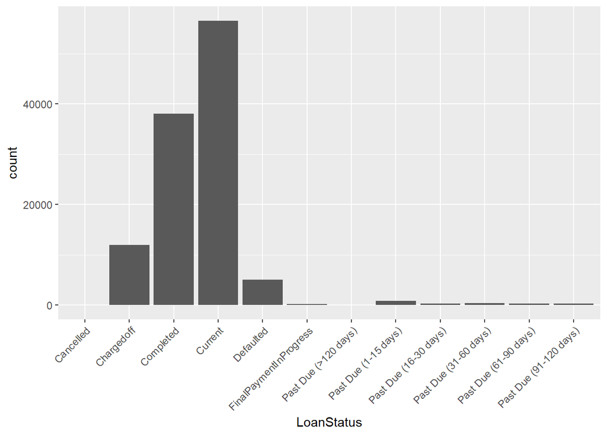

Plotting a histogram of the loan statuses in the dataset shows, that the majority of loans are either “current” or “completed”. A significant portion of loans are also either “Chargedoff” or “defaulted”. As far as I understood (I`m not a native English speaker and don´t know much about US loan terminology) both are statuses where the customer is unable to pay his monthly payments. Together these two statuses comprise around 17.000 customers, or ca. 15% of all customers. Additionally there is a minority of customers that are due on their payments for more than 120 days (after 180 days of non payment the account gets charged-off?). So that there is a significant portion of customers not able to pay back their loans.

## Term

```
##    Min. 1st Qu.  Median    Mean 3rd Qu.    Max.
##   12.00   36.00   36.00   40.83   36.00   60.00
```

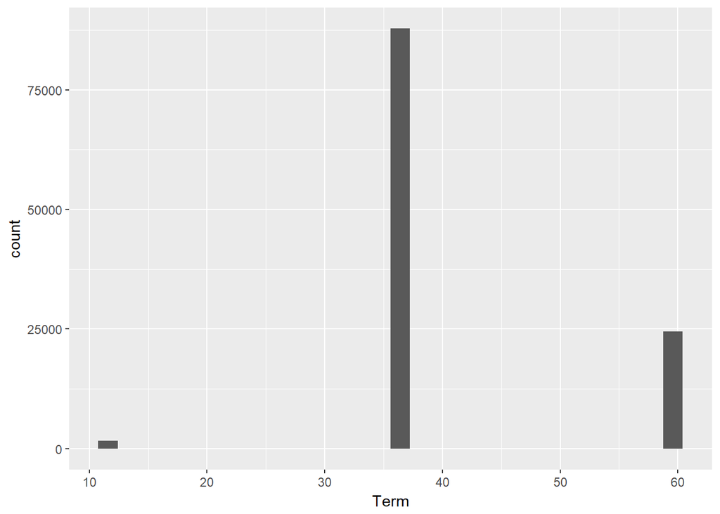

Looking at the distribution of the loan terms reveals, that there are only three term options: 12, 36 or 60 months. 36 months is by far the most popular option, while 12 months is the least popular one

## Credit grades

```
##           A    AA     B     C     D     E    HR    NC
## 84984  3315  3509  4389  5649  5153  3289  3508   141
```

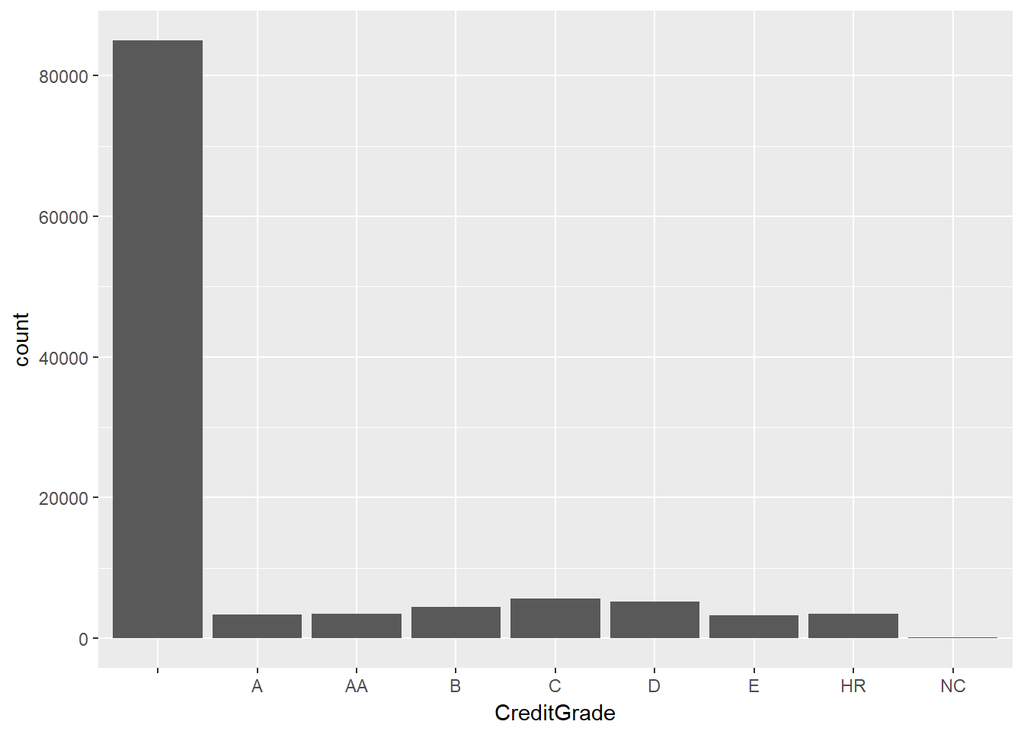

From the summary and the frequency for each of the credit grades one can immediately see that the largest portion of loans (ca. 85.000) have a credit grade of “”. So these loans seem not to be graded and only around 30.000 of the loans have been graded. To better look at the graded loans I created a subset of loans that do not have a grade of “”.

## Cleaned credit grades

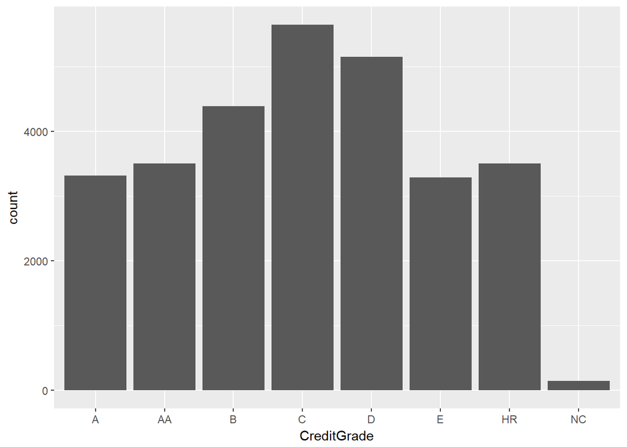

Looking at the graded loans only, one can see that the number of loans per grade are quite equally distributed, except for loans graded “NC”. There are only ca. 140 loans with this grade. For the other grades there are roughly between 3300 and 5700 loans per grade. The most frequent grade is “c”. Another thing I noticed is that the order of grades is propably not correct. I would think that the best grade would be “AA”, so I reordered the grades so that “AA” is the first in the plot. This means I assume the order of grades from best to worst is “AA”, “A”, “B”, “C”, “D” to “E”. I actually don´t know what a grade of “HR” or “NC” means.

## Reordered grades

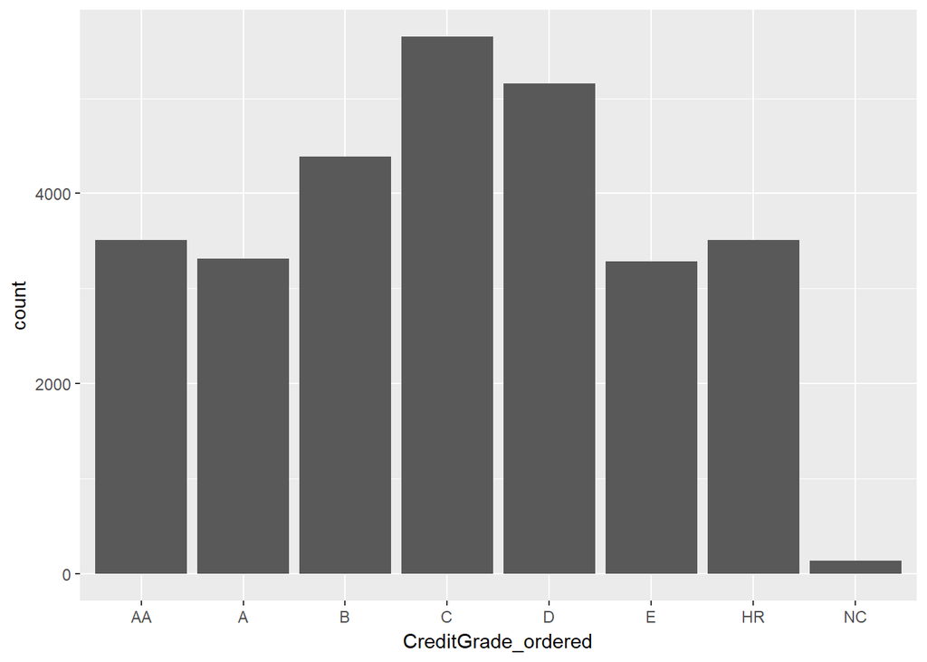

Then I was interested in all those loans that are not graded (or graded “”), so I investigated further. I created a subset containing only loans ungraded loans and looked at LoanStatus of this subset.

```
##              Cancelled             Chargedoff              Completed
##                      0                   5342                  19786
##                Current              Defaulted FinalPaymentInProgress
##                  56576                   1008                    205
##   Past Due (>120 days)   Past Due (1-15 days)  Past Due (16-30 days)
##                     16                    806                    265
##  Past Due (31-60 days)  Past Due (61-90 days) Past Due (91-120 days)
##                    363                    313                    304
```

So ungraded loans have a mix of almost all the different loan statuses, but the majority (ca. 56.000 out of 85.000) are “current” loans. While there is also a significant number of loans with the status “completed”, most of the ungraded loans are “current” or in one form or another past due.

The grading for these loans without a credit grade can be found in at least two other variables: ProsperRating..Alpha. and ProsperRating..numeric.

```
##           A    AA     B     C     D     E    HR
##   131 14551  5372 15581 18345 14274  9795  6935
```

```
##    Min. 1st Qu.  Median    Mean 3rd Qu.    Max.    NA's
##   1.000   3.000   4.000   4.072   5.000   7.000     131
```

Although there are a few loans that also do not have a ProsperRating (131), Credit grade and the ProsperRating seem to be mutually exclusive. From a subset of only loans that do not have a credit grade of “”, none of the loans has a ProsperRating:

```
##    Min. 1st Qu.  Median    Mean 3rd Qu.    Max.    NA's
##      NA      NA      NA     NaN      NA      NA   28953
```

```
##           A    AA     B     C     D     E    HR
## 28953     0     0     0     0     0     0     0
```

I then looked at the variable definition for this dataset, which explains this mutual exclusivity: The credit grade was only applied for loans originating pre-2009, while the ProsperRating was introduced for loans issued after July 2009.

I then ordered the ProsperRating..Alpha. in the same way as I did for the credit grades and plotted histograms for credit grades and prosper rating beneath each other:

## Distribution of credit grades and Prosper rating

```
##           A    AA     B     C     D     E    HR
##     0 14551  5372 15581 18345 14274  9795  6935
```

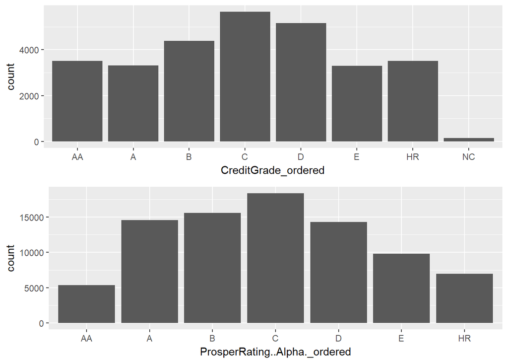

Both before and after July 2009 most of the loans are rated “C”. Interestingly the proportion of loans rated “AA” is significantly lower for loans originating after July 2009. Thus the distribution of grades after July 2009 looks closer to a normal distribution then the distribution of credit grades pre-2009, which is more uniform.

## Income

Next I was interested in the Income of the customers taking out a loan. There are two variables regarding the income I looked at. One is the income range:

### IncomeRange

```
##             $0      $1-24,999      $100,000+ $25,000-49,999 $50,000-74,999
##            621           7274          17337          32192          31050
## $75,000-99,999  Not displayed   Not employed
##          16916           7741            806
```

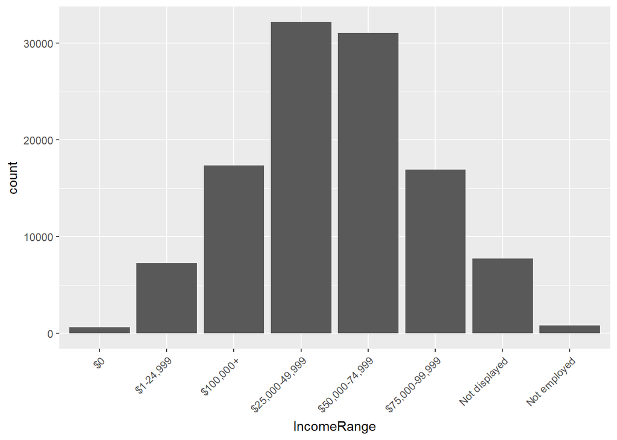

The income range is a factor with 8 levels, with one level spanning 25,000$ in general. There are exceptions: There is a level for an income of 0, as well as for customers that are not employed or where the income range is not displayed.

From the histogram one can see that most loans are taken out by customers with an income in the range of 25,000 to 75,000$. The income ranges are not fully in order so I created a new variable for the ordered ranges:

## Income range reordered

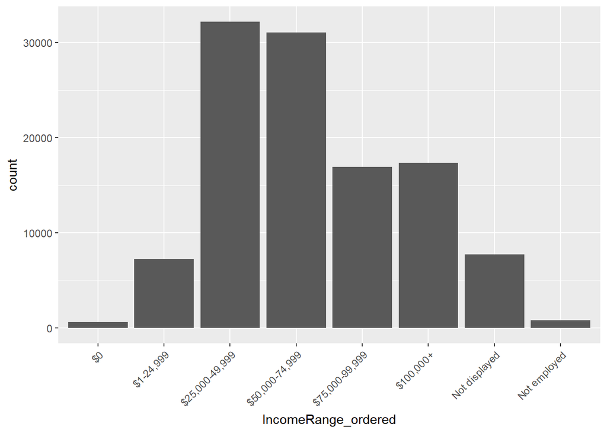

It was a bit surprising for me to see that such a big number of customers (>30,000) with an income >75,000$ are taking out loans. It would be interesting the see the distribution of income ranges of the general (US?) population in comparison. I would assume that high income ranges (>75,000$) are overrepresented in this dataset.

The other factor I looked at regarding income is StatedMonthlyIncome:

```
##    Min. 1st Qu.  Median    Mean 3rd Qu.    Max.
##       0    3200    4667    5608    6825 1750003
```

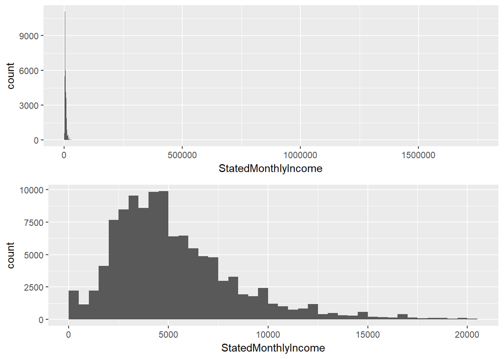

The distribution of the stated monthly income is extremely longtailed. While the third quartile is at 6825$, the maximum lies at 1750003$. Plotting the stated monthly income without further adjustments reveals the huge range in monthly incomes. Looking at the distribution of the 99% quantile, one can see that 99% of customers have a stated monthly income of 20.000$ or less. The vast majority of customers have a stated monthly income of less than 10.000$. The mode of this distribution is at an income of around 5000$, while the median is at 4667$.

I then checked what the number of verifiable incomes is:

```
##  False   True
##   8669 105268
```

Interestingly most of the stated incomes are verified (>100,000), which indicates that the huge range in stated incomes are actually present in reality and not outliers due to self reporting.

## ListingCategory

```
##    Min. 1st Qu.  Median    Mean 3rd Qu.    Max.
##   0.000   1.000   1.000   2.774   3.000  20.000
```

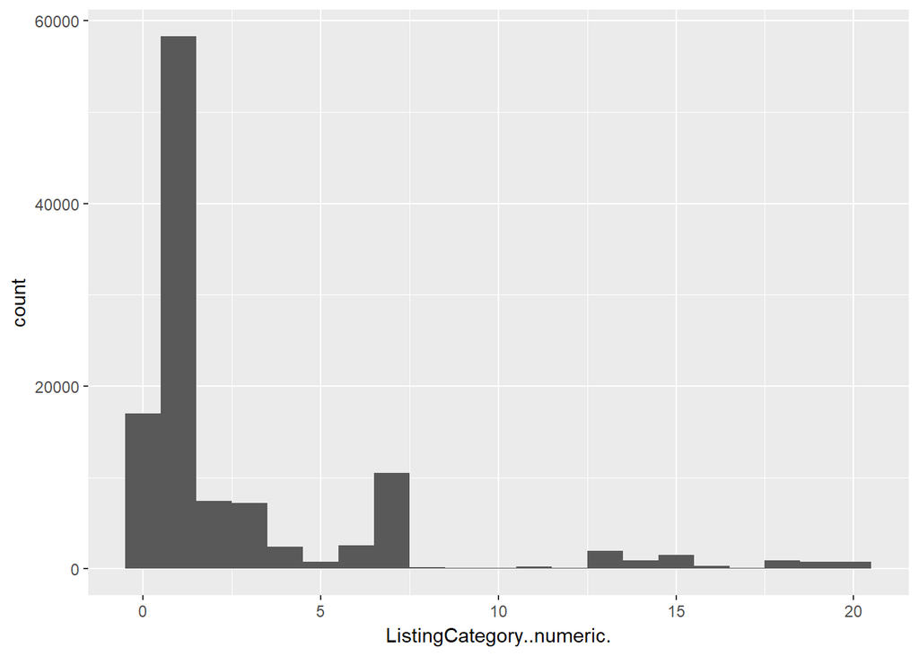

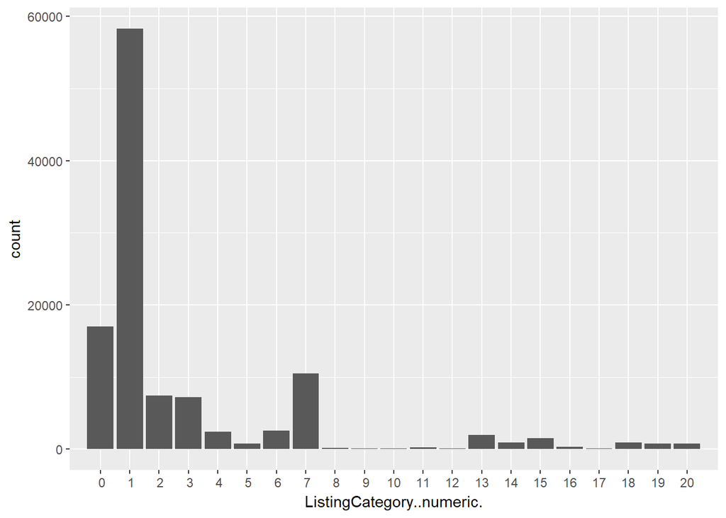

Legend for the Listing categories:

0 - Not Available 1 - Debt Consolidation 2 - Home Improvement 3 - Business 4 - Personal Loan 5 - Student Use 6 - Auto 7 - Other 8 - Baby&Adoption 9 - Boat 10 - Cosmetic Procedure 11 - Engagement Ring 12 - Green Loans 13 - Household Expenses 14 - Large Purchases 15 - Medical/Dental 16 - Motorcycle 17 - RV 18 - Taxes 19 - Vacation 20 - Wedding Loans

The variable ListingCategory..numeric. is a very interesting one, since it contains the purpose a loan was taken out for. Each of the 20 different purposes is assigned to a numerical value as listed above.

The most frequent category customers listed was “debt consolidation”. Around half of all the loans in this dataset were taken out for this reason. The next most frequent categories are “Not Available” and “Other”, which unfortunately do not tell us anything about what the loan was used for. Other frequent categories that tell us something about the purpose of the loan are “Business” and “Home Improvement”.

It is quite striking to me seeing that most of the customers are taking out these loans in order to consolidate debt. So they are getting into additional debt in order to pay off some other debt. Possible explanations for this phenomenon would be that these loans are quite easy to obtain, i.e. that customers do not have to go through a very rigorous scrutiny of their financial standing. Or it could indicate that these loans are offered at very attractive conditions so making it worthwhile to take out one of these loans to pay off another one.

This motivated me to look into this listing category in more detail.

## Subset for debt consolidation category

```
##             $0      $1-24,999 $25,000-49,999 $50,000-74,999 $75,000-99,999
##             97           2831          16857          18119          10039
##      $100,000+  Not displayed   Not employed
##          10099              0            266
```

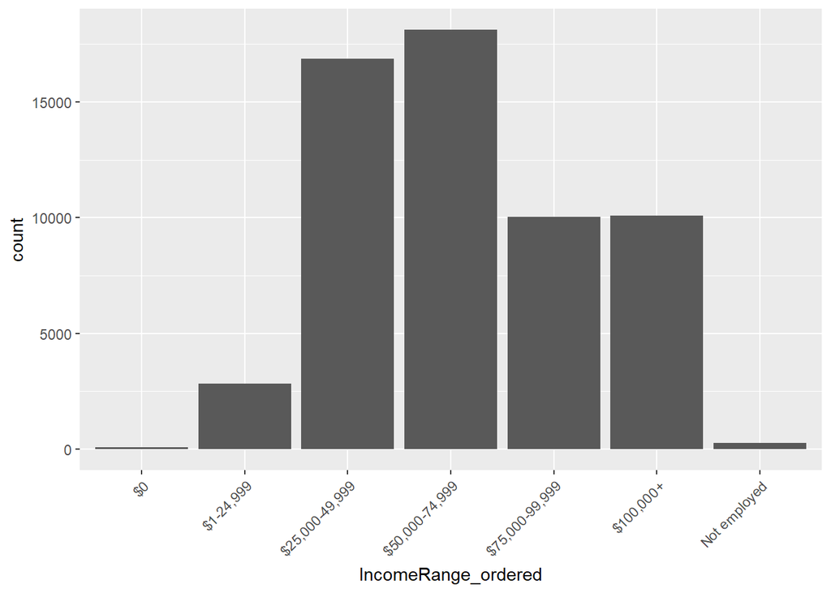

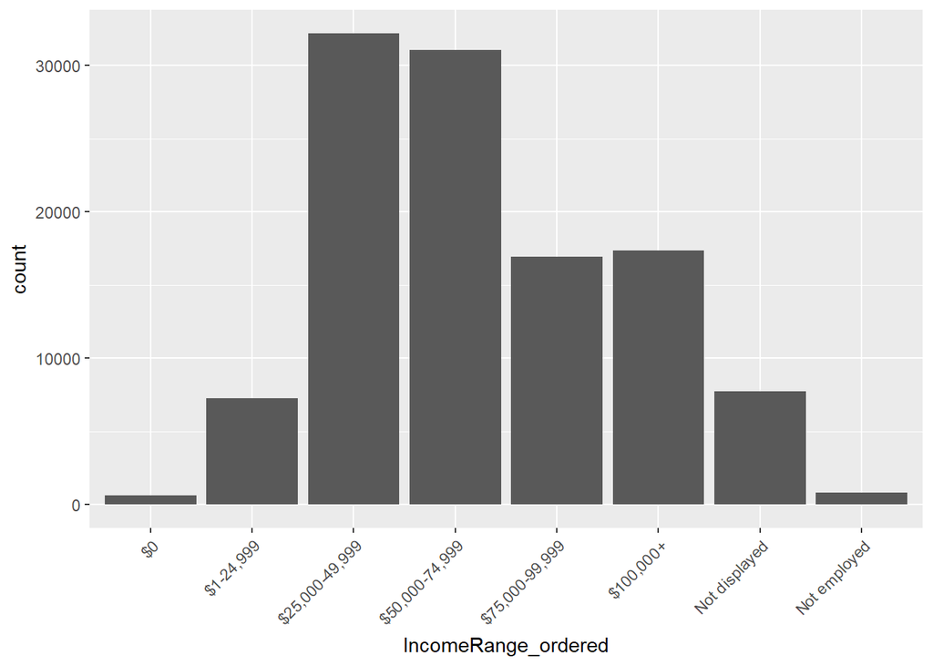

## Number of loans per customer

```
##    Min. 1st Qu.  Median    Mean 3rd Qu.    Max.    NA's
##    2.00   17.00   25.00   26.75   35.00  136.00     697
```

```
##    Min. 1st Qu.  Median    Mean 3rd Qu.    Max.
##    2.00   19.00   27.00   28.49   36.00  136.00
```

Looking at the number of credit lines a customer had in the past 7 years, shows that customers, who took out a loan for “Debt Consolidation” had had in median 2 more credit lines when compared to the overall dataset. The average is also around 2 bigger in the “Debt Consolidation” subset. Since loans in the category debt consolidation make up around half of all the loans in this dataset, the numbers for the overall dataset are heavily influenced by/skewed towards the “Debt Consolidation” category. The higher number of credit lines in the past 7 years might indicate that debt consolidation is a continuous process for many customers that requires taking out loans one after another (this is pretty speculative).

## Borrower Rate

```
##    Min. 1st Qu.  Median    Mean 3rd Qu.    Max.
##  0.0000  0.1340  0.1840  0.1928  0.2500  0.4975
```

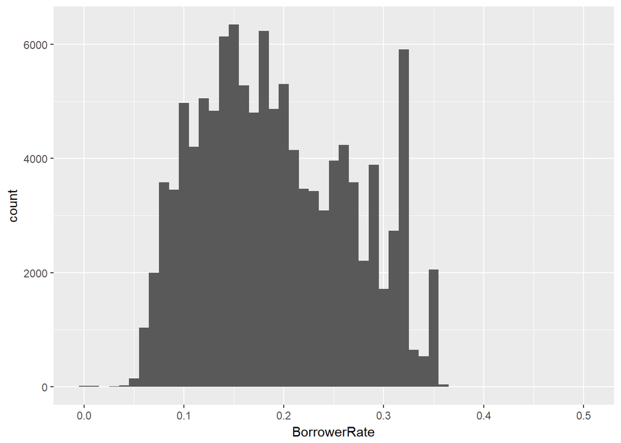

```
##    Min. 1st Qu.  Median    Mean 3rd Qu.    Max.
## -0.0100  0.1242  0.1730  0.1827  0.2400  0.4925
```

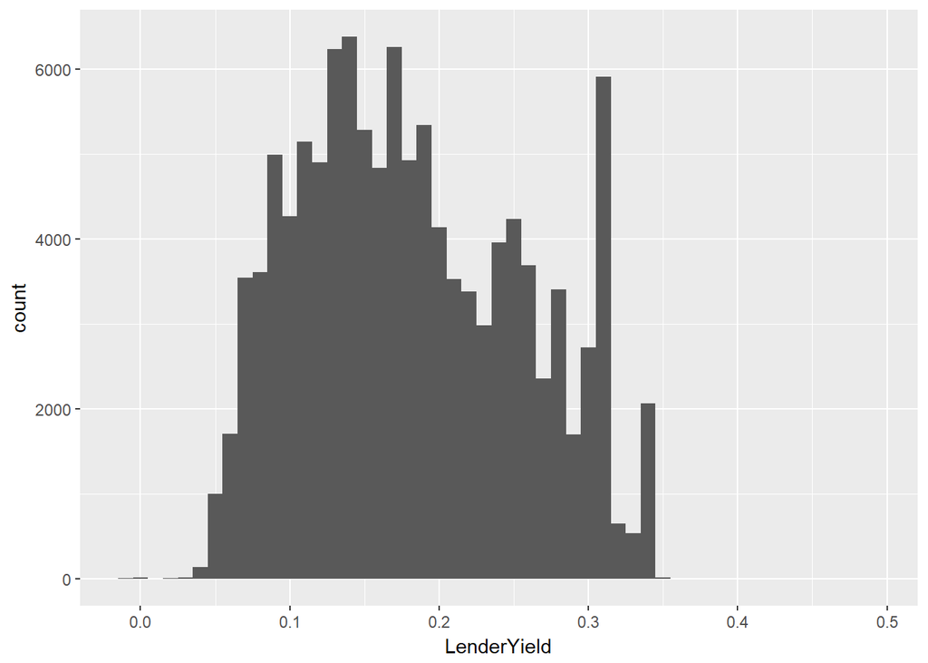

Next I looked at the interest rates for the loans (BorrowerRate) and the LenderYield respectively. According to the variable definitions for this dataset, the LenderYield is equal to the BorrowerRate minus service fees. The summaries and plots for BorrowerRate (top) and LenderYield (bottom) confirm this. The median, mean and histograms are very similar. The most frequent rates are at 0.14, 0.15 and 0.18. There is also a peak at the higher end of the spectrum at ca. 0.32. Interestingly there are a few loans at an interest rate of 0.

## Loaned amount

```
##    Min. 1st Qu.  Median    Mean 3rd Qu.    Max.
##    1000    4000    6500    8337   12000   35000
```

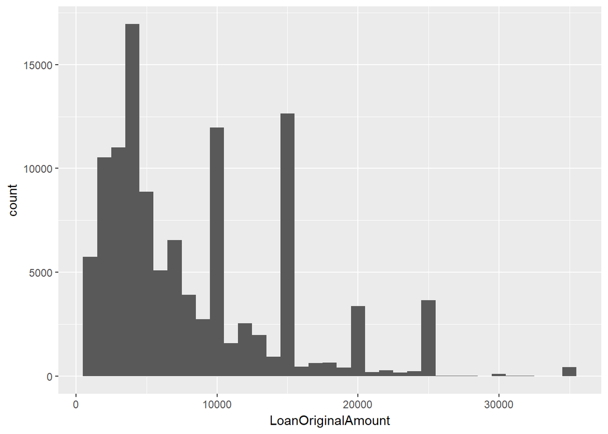

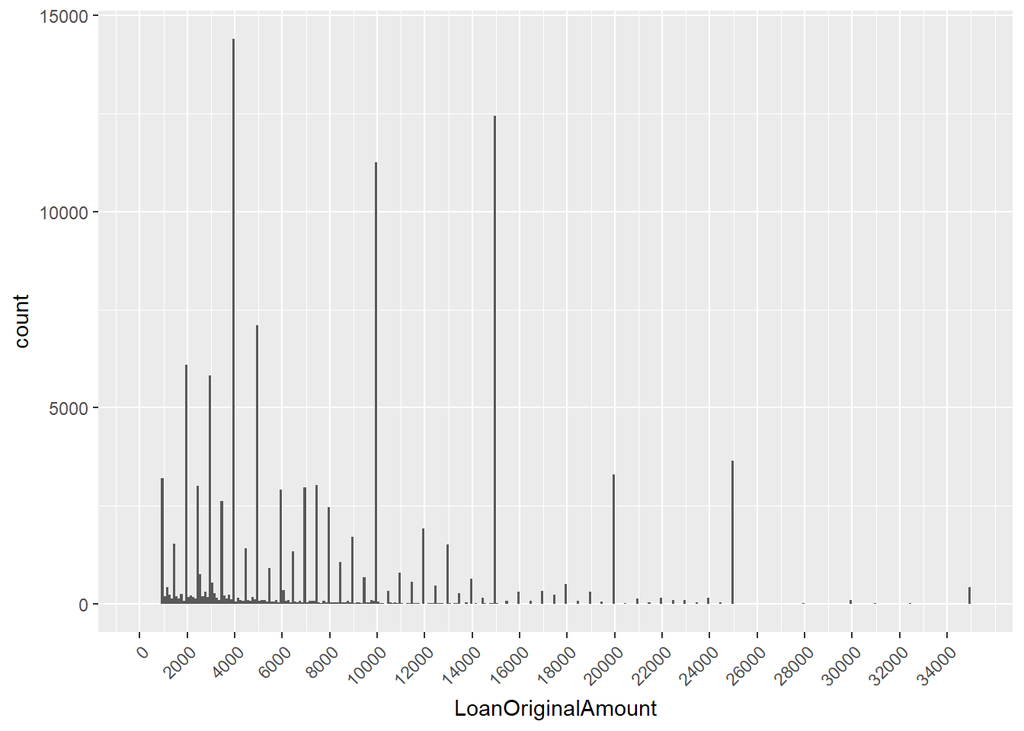

Looking at the amount of money customers originally borrowed, we can see that the minumum loan that can be taken up is 1000$. The maximum amounts that were borrowed were 35.000$. The median is at 6500$, while the average is at 8337$.

The distribution of loan amount is positively skewed, with the majority of customers borrowing less than 10.000$. Setting the bin size to 100, one can see very distinct peaks for certain amounts. Usually there is a peak every 1000$. Amounts deviating from a multiple of 1000 seem to be unpopular. The biggest peak can be observed for an amount of 4000$. There are similarly high peaks at 10.000 and 15.000$.

## Monthly Loan payment

```
##    Min. 1st Qu.  Median    Mean 3rd Qu.    Max.
##     0.0   131.6   217.7   272.5   371.6  2251.5
```

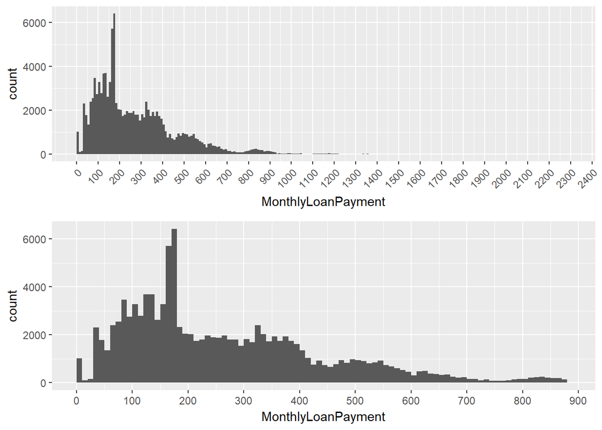

Looking at the monthly loan payment, we find that the median payment is 217.7$, the mean 272.5$ and the maximum is 2251.5$. Considering the 3rd quartile with 371.6$, one can assume that the maximum is an extreme outlier. Plotting histograms of the monthly loan payments, both of the full range of amounts and of the 99% quantile, shows that 99% of monthly loan payments are below 900$. So the maximum is indeed an outlier.

The mode of the distribution is slightly below 200$, with a steep decrease in frequency for larger amounts.

Another interesting point is the minimum payment of 0$ by ca. 1000 customers. One possible explanation might be customers temporarily deferring their payments or that are unable to pay back the loan.

## Number of Investor

```
##    Min. 1st Qu.  Median    Mean 3rd Qu.    Max.
##    1.00    2.00   44.00   80.48  115.00 1189.00
```

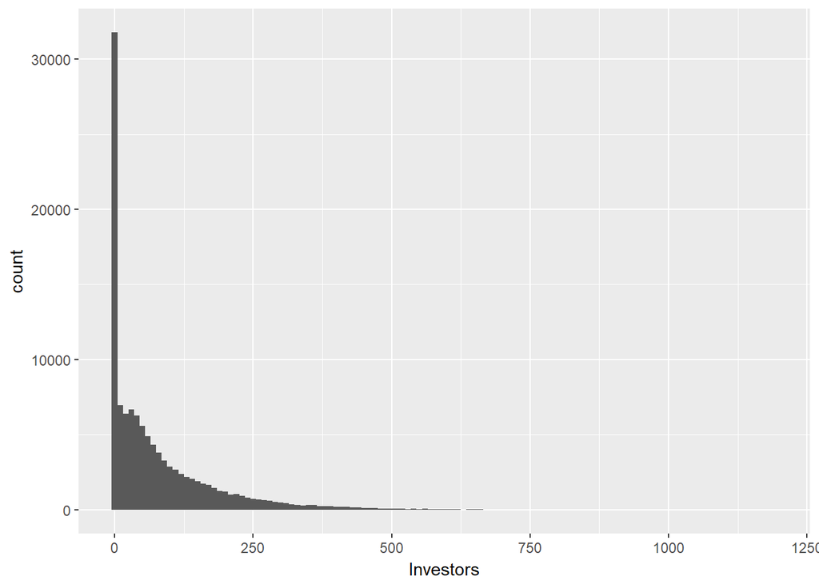

The distribution of the number of investors funding each of the loans is positively skewed and very long-tailed. The range is quite huge, with a minimum of 1 and a maximum of 1189 investors funding a loan. The most frequent number of investors for a loan is between 1 and 10, which is the case for ca. 25% of the loans in the dataset. The number of loans funded by higher numbers of investors decreases as the number of investors funding a loan increases.

# Univariate Analysis

### What is the structure of your dataset?

There are 113937 loans in this dataset with 81 variables per observation. These are to many variables to consider in the scope of this project.

LoanStatus is an unordered factor variable with 12 levels.

CreditGrade (and ProsperRating..Alpha.) is an ordered factor with 9 levels: from AA (best) to E (worst?) (this is the order I assumed. It is not explicitly stated in the variable definitions and I don´t know where the levels “HR” and “NC” rank in this rating)

IncomeRange is also an ordered factor variable with 8 levels: $0, $1-24.999, $25.000-49.999, $50.000-74.999, $74.999-99.999, $100.000+, “Not displayed” and “Not employed”.

StatedMonthlyIncome is a numerical variable with a minimum of 0, a maximum of 1.750.003 and a median of 4667.

ListingCategory..numeric. is an integer variable with each integer being assigned to one of the listing categories:

0 - Not Available 1 - Debt Consolidation 2 - Home Improvement 3 - Business 4 - Personal Loan 5 - Student Use 6 - Auto 7 - Other 8 - Baby&Adoption 9 - Boat 10 - Cosmetic Procedure 11 - Engagement Ring 12 - Green Loans 13 - Household Expenses 14 - Large Purchases 15 - Medical/Dental 16 - Motorcycle 17 - RV 18 - Taxes 19 - Vacation 20 - Wedding Loans

Around half of all the loans in this dataset are listed as category 1, i.e debt consolidation.

TotalCreditLinespast7years is also an integer variable with a minimum of 2, a maximum of 136 and a median of 25.

BorrowerRate and LenderYield are both numerical variables. BorrowerRate has a minimum of 0, a maximum of 0.4975 and a median of 0.184. The minimum of LenderYield is -0.01, while the maximum is 0.4925 and the median 0.173.

LoanOriginalAmount is a integer variable with a minimum of 1000, a maximum of 35.000 and a median of 6500.

MonthlyLoanPayment is a numerical variable with a minimum of 0, a maximum of 2251.5 and a median of 217.7.

### What is/are the main feature(s) of interest in your dataset?

The main features I´m interested in are the LoanOriginalAmount, MonthlyLoanPayment, BorrowerRate which I´d like to explore in their relationship to time, term and CreditGrade/Rating.

### What other features in the dataset do you think will help support your investigation into your feature(s) of interest?

As mentioned above, the date, term and rating of the loan as well as the LoanStatus and IncomeRange/StatedMonthlyIncome of the customer.

### Did you create any new variables from existing variables in the dataset?

I created a new variable for the ratio between the MonthlyLoanPayment and the StatedMonthlyIncome. I also created a new variable for the reordered CreditGrade. Furthermore I converted the ListingCreationDate into a date in the format %Y-%m-%d and stored this as a factor in a new LoanDate variable.

### Of the features you investigated, were there any unusual distributions? Did you perform any operations on the data to tidy, adjust, or change the form of the data? If so, why did you do this?

I reordered the CreditGrade/ProsperRating..Alpha. variable from AA to E and also created a subset removing all loans with a CreditGrade of “”. I also reordered the IncomeRange variable so that the ranges are in ascending order.

StatedMonthlyIncome shows an usual distribution. It is positively skewed but extremely longtailed. The maximum is at 1.750.003$ while the 99% quantile is around 20.000$.

As mentioned above I converted the ListingCreationDate into a factor in %Y-%m-%d format in order to remove the excact time of day a listing was created. I did this so that calculating and plotting e.g. a mean for each day was easier.

# Bivariate Plots Section

## Number of Investor

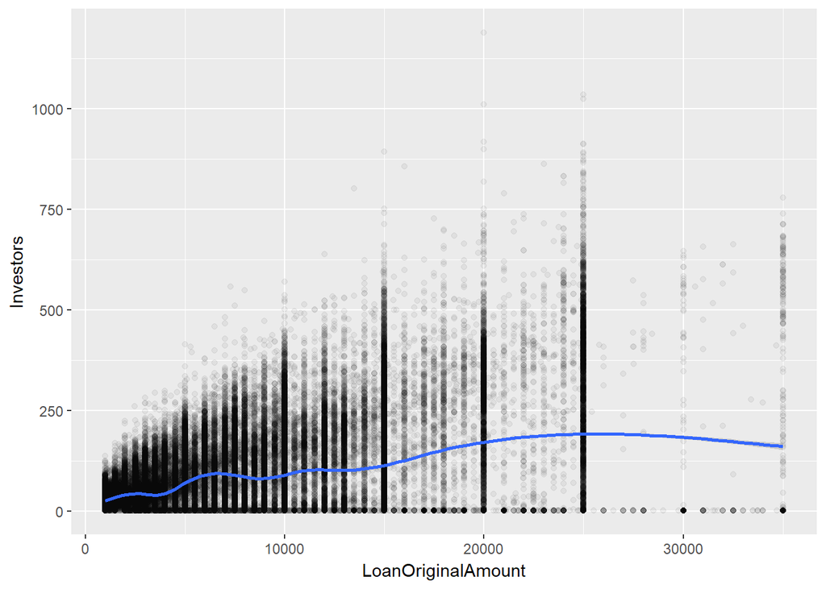

Next I looked at the relationship between the LoanOriginalAmount and the number of investors funding a loan. Overall there is a slight trend of increasing numbers of investors as the amount of the loans increase. At the same time we can see that the variance in the number of investors strongly increases as the loaned amount increases. So it seems that while there is a relationship between the amount of a loan and the number of investors funding it, there are probably other variables affecting the number of investors. One thing that is not clear from this dataset is the amount every investor is funding a loan with. So possibly a higher number of investors is necessary if each investor is only funding a loan with a moderate sum. If there is any kind of limitation on how much money an investor can put into a single loan, this alone would explain the general increase of investors as the loan amount increases.

I would assume that the number of investors could also be seen as an indicator of risk. This would mean that probably fewer investors were willing to fund risky loans, while safer loans would find more investors. So I looked for relationships between the number of investors and other variables that could be indicative of the risk associated with a loan.

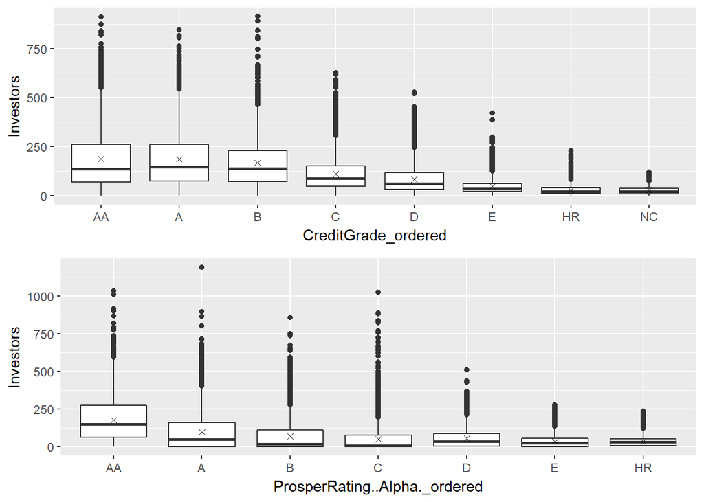

```r
# Investors vs CreditGrade
pInvGrade <- ggplot(aes(x = CreditGrade_ordered, y = Investors),
       data = grades_clean) +
  geom_boxplot() +
  stat_summary(fun.y = mean, geom = 'point', shape = 4 )

# Investors vs ProsperRating

# subset removing ProsperRating of ""

RatingSub <- subset(loans, loans$ProsperRating..Alpha. != "")

RatingSub$ProsperRating..Alpha._ordered <-
  factor(ProsperRatingSub$ProsperRating..Alpha.,
    levels = c("AA", "A", "B","C","D","E","HR","NC",""))

pInvRating <- ggplot(aes(x = ProsperRating..Alpha._ordered, y = Investors),
       data = RatingSub) +
  geom_boxplot() +
  stat_summary(fun.y = mean, geom = 'point', shape = 4 )

grid.arrange(pInvGrade, pInvRating, ncol = 1)
```

So next I plotted the number of investors vs the CreditGrade and ProsperRating respectively. The rating of a loan is also indicative of the risk associated with the loan. Loans with the best rating (AA) are less risky for the funder than loans rated E. From the plots one can see that there is a clear trend of decreasing numbers (mean, median) of investors from loans with the best to the worst rating. So one can assume that the riskier a loan, the less investors funding it. Interestingly after introdution of the new ProsperRating system in July 2009, the difference in investor numbers between AA and all the other ratings is more pronounced. From the histograms of CreditGrade and ProsperRating we can see that after July 2009 loans with AA rating are proportionally much rarer than in the CreditGrade sytem pre-2009. One could speculate that after the financial crisis 2008, getting an AA rating became more difficult and investors were more interested in security and thus preferred funding AA rated loans.

There is still a lot of variance in investors numbers per credit rating, so I looked at another factor that might have an influence on the number of investors per loan. This is the number of investors plotted against the LenderYield (which is the interest rate a customer pays minus service fees):

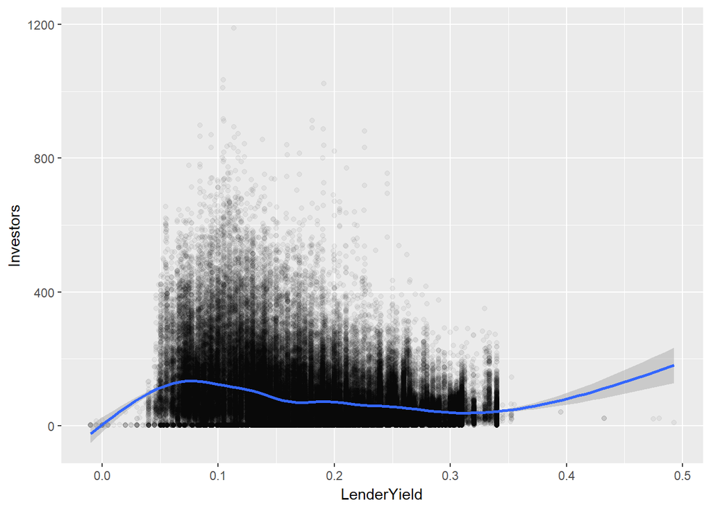

One can see that investor funding a loan peak at loans with a LenderYield of around 0.1. These loans probably represent low risk but also low yield loans. The number of investors then decreases as the LenderYield increases, although there is a slight uptick in investor number for loans with a yield > 0.3. So in general one could assume that the higher the risk, the fewer investors fund a loan. But if the yield for the investor is high (attractive) enough, it might be an incentive to take the risk and fund such a loan.

## LenderYield/BorrowerRate vs CreditGrade

```
## grades_clean$CreditGrade_ordered: AA
##     Min.  1st Qu.   Median     Mean  3rd Qu.     Max.
## -0.00500  0.07250  0.08320  0.09233  0.10500  0.31380
## --------------------------------------------------------
## grades_clean$CreditGrade_ordered: A
##    Min. 1st Qu.  Median    Mean 3rd Qu.    Max.
## -0.0100  0.0890  0.1090  0.1168  0.1337  0.3400
## --------------------------------------------------------
## grades_clean$CreditGrade_ordered: B
##    Min. 1st Qu.  Median    Mean 3rd Qu.    Max.
## -0.0099  0.1150  0.1320  0.1432  0.1612  0.3400
## --------------------------------------------------------
## grades_clean$CreditGrade_ordered: C
##    Min. 1st Qu.  Median    Mean 3rd Qu.    Max.
## -0.0100  0.1315  0.1580  0.1691  0.1925  0.3475
## --------------------------------------------------------
## grades_clean$CreditGrade_ordered: D
##    Min. 1st Qu.  Median    Mean 3rd Qu.    Max.
## -0.0050  0.1550  0.1900  0.2011  0.2320  0.3450
## --------------------------------------------------------
## grades_clean$CreditGrade_ordered: E
##    Min. 1st Qu.  Median    Mean 3rd Qu.    Max.
##  0.0000  0.2050  0.2440  0.2435  0.2800  0.3550
## --------------------------------------------------------
## grades_clean$CreditGrade_ordered: HR
##    Min. 1st Qu.  Median    Mean 3rd Qu.    Max.
## -0.0100  0.1995  0.2500  0.2425  0.2850  0.4925
## --------------------------------------------------------
## grades_clean$CreditGrade_ordered: NC
##    Min. 1st Qu.  Median    Mean 3rd Qu.    Max.
##  0.0450  0.1650  0.2150  0.2087  0.2650  0.3245
## --------------------------------------------------------
## grades_clean$CreditGrade_ordered:
## NULL
```

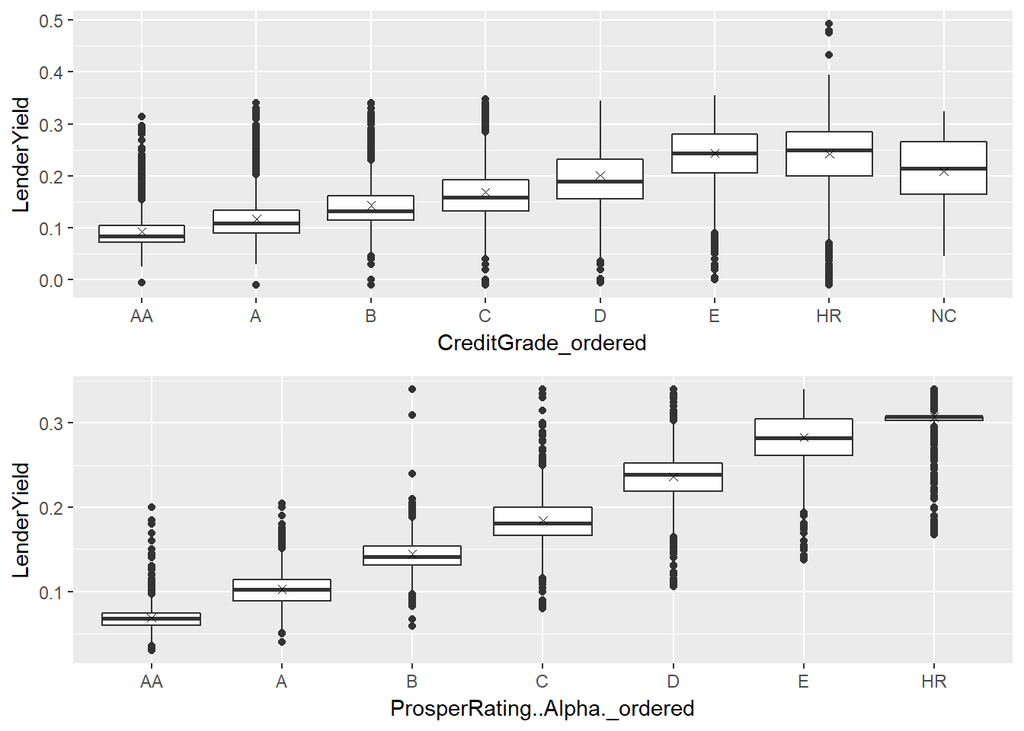

```
## RatingSub$ProsperRating..Alpha._ordered: AA
##    Min. 1st Qu.  Median    Mean 3rd Qu.    Max.
## 0.03000 0.05990 0.06790 0.06911 0.07450 0.20000
## --------------------------------------------------------
## RatingSub$ProsperRating..Alpha._ordered: A
##    Min. 1st Qu.  Median    Mean 3rd Qu.    Max.
##  0.0398  0.0890  0.1019  0.1029  0.1139  0.2050
## --------------------------------------------------------
## RatingSub$ProsperRating..Alpha._ordered: B
##    Min. 1st Qu.  Median    Mean 3rd Qu.    Max.
##  0.0593  0.1314  0.1409  0.1444  0.1539  0.3400
## --------------------------------------------------------
## RatingSub$ProsperRating..Alpha._ordered: C
##    Min. 1st Qu.  Median    Mean 3rd Qu.    Max.
##  0.0795  0.1665  0.1814  0.1844  0.1999  0.3400
## --------------------------------------------------------
## RatingSub$ProsperRating..Alpha._ordered: D
##    Min. 1st Qu.  Median    Mean 3rd Qu.    Max.
##  0.1057  0.2187  0.2392  0.2364  0.2525  0.3400
## --------------------------------------------------------
## RatingSub$ProsperRating..Alpha._ordered: E
##    Min. 1st Qu.  Median    Mean 3rd Qu.    Max.
##  0.1379  0.2612  0.2825  0.2833  0.3049  0.3400
## --------------------------------------------------------
## RatingSub$ProsperRating..Alpha._ordered: HR
##    Min. 1st Qu.  Median    Mean 3rd Qu.    Max.
##  0.1679  0.3034  0.3077  0.3073  0.3077  0.3400
## --------------------------------------------------------
## RatingSub$ProsperRating..Alpha._ordered: NC
## NULL
## --------------------------------------------------------
## RatingSub$ProsperRating..Alpha._ordered:
## NULL
```

In order to visualize the incentive of higher risk loans for investors, I plotted the LenderYield against the respective CreditGrade or ProsperRating. The plots clearly show that the median (and mean) LenderYield increases from the best (AA) to the worst rating (E). One can also see from the plots, that after introducing the ProsperRating system in 2009, the differences in yield between the rating got more pronounced. The median yield for AA rated loans is lower than for loans pre-2009 (CreditGrade), while the median yield for E rated loans is higher. For the CreditGrade system the median LenderYield ranges from 0.083 (AA) to 0.244 (E). For the ProsperRating system the median LenderYield ranges from 0.068 (AA) to 0.282 (E).

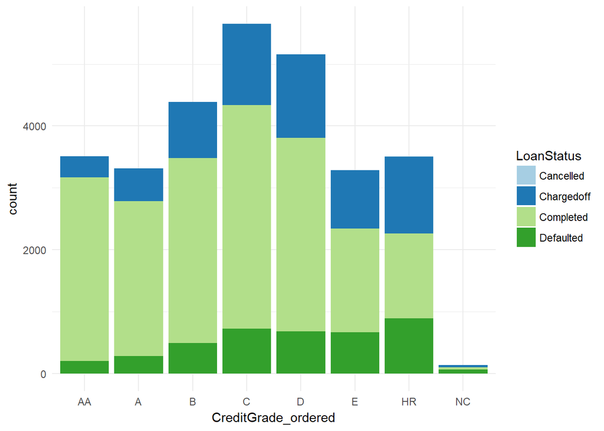

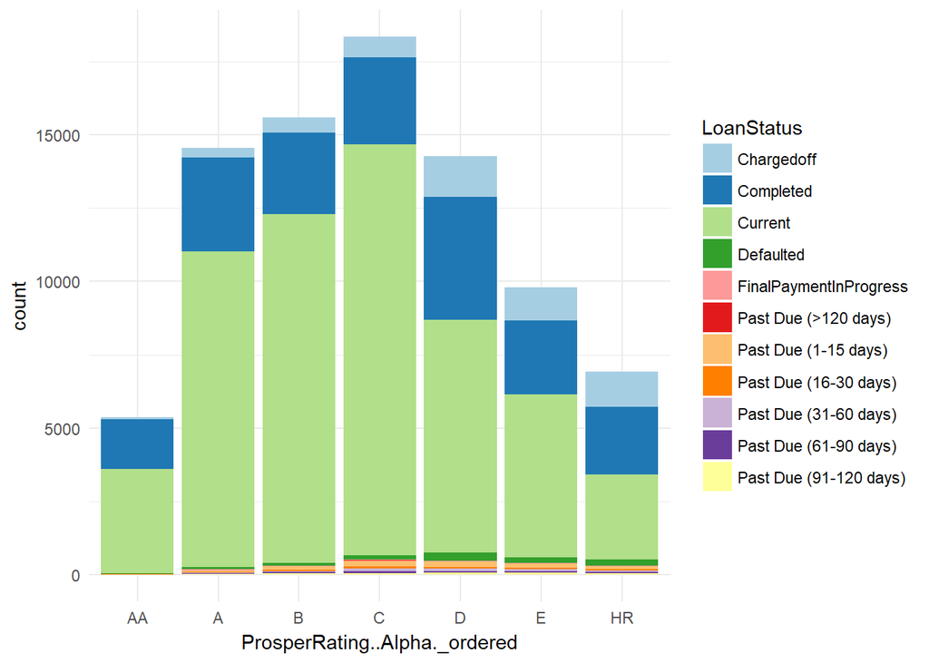

In order to illustrate why worse credit grades/ratings are indicative for higher risk loans, I plotted the grades/ratings and colored them by the LoanStatus. The first thing that struck me are the much more granular LoanStatus levels that were apparently introduced alongside the ProsperRating system in 2009. When the CreditGrade system had only 4 levels, the ProsperRating system had 11.

Overall one can see that for both rating systems the number of loans that are in some form overdue increases from the best rating (AA) to the worst (E). So it is more common for loans rated “E” to be past due, defaulted, chargedoff or cancelled. This is probably constitutes a significant portion of the risk associated with a given loan.

## Income range per loan rating

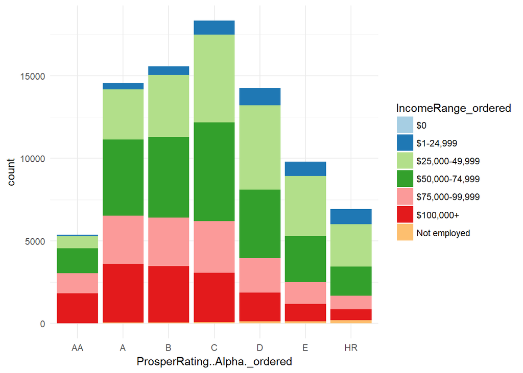

Another factor that I looked at regarding the different ratings is the income range. The portion of high income customers (>75.000$) among loans rated “AA” is much higher than among loans rated “E”. Accordingly the portion of lower income customers (<50.000$) increases from the best rating to the worst rating. So there probably is a relationship between the income of the customer and the rating of a given loan. One could assume that the income is a factor determining the loan rating.

## Ratio of monthly payment/income vs StatedMonthlyIncome

```
##      Min.   1st Qu.    Median      Mean   3rd Qu.      Max.
##     0.000     0.028     0.049     8.157     0.077 12571.730
```

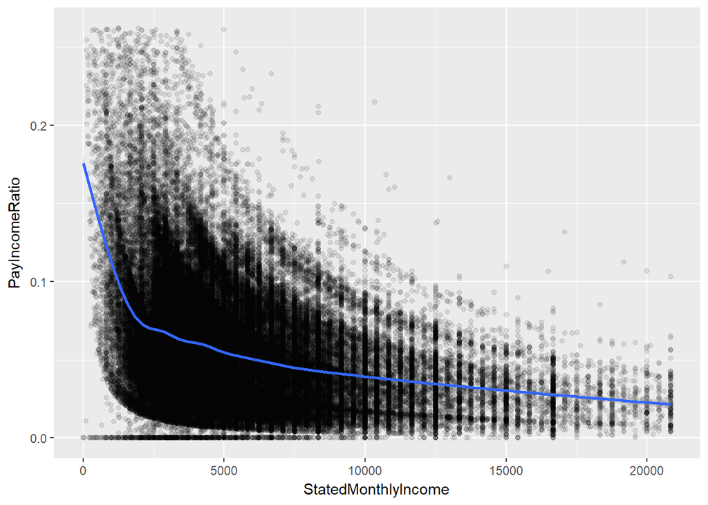

Next I wanted to visualize the proportion of their stated income customers have to pay in their monthyl loan payments. For this reason I created a new variable (“PayIncomeRatio”) by calculating: MonthlyLoanPayment / StatedMonthlyIncome (after removing incomes of 0). Looking at the summary for this ratio one can see that there is an extreme range for this variable: from 0 to 12571.73. These extreme values are on the one hand due to monthly loan payments of 0, resulting in a ratio of 0, and on the other hand due to very low incomes (the lowest that is not 0 is 0.083) with a monthly payment of around 1000$. Therefore I decided to only plot the 99% quantile for both the ratio and the income.

Unsurprisingly one can see from the plot, that as the income increases the ratio of monthly payment/income decreases. Furthermore the variance in the ratio also decreases. So customers with a higher income need to spend a smaller proportion of their monthly income for paying off the loans the took out.

## MonthlyLoanPayment vs LoanOriginalAmount

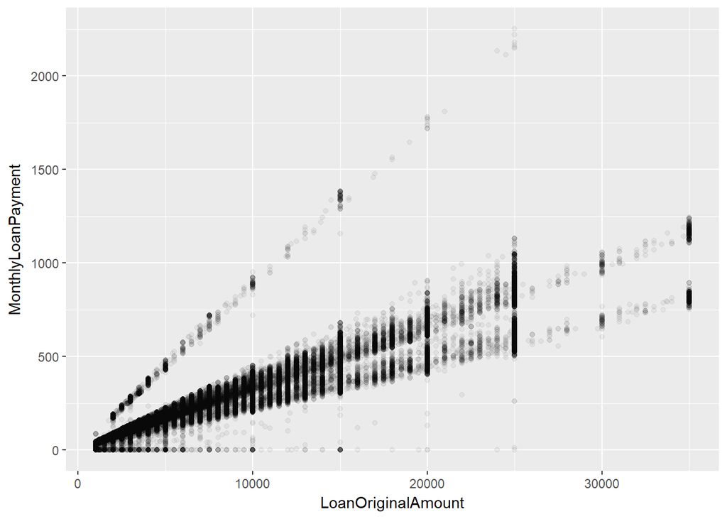

Plotting the LoanOriginalAmount against the MonthlyLoanPayment reveals (unsurprisingly) a positive linear relation between the amount of money loaned and the monthly payment. Interestingly one can see 3 distinct groups, which could be represented as 3 distinct trend lines with different slopes. So there seem to be 3 distinct groups where the customers pay different amounts per month for the same total amount loaned.

## BorrowerRate over time

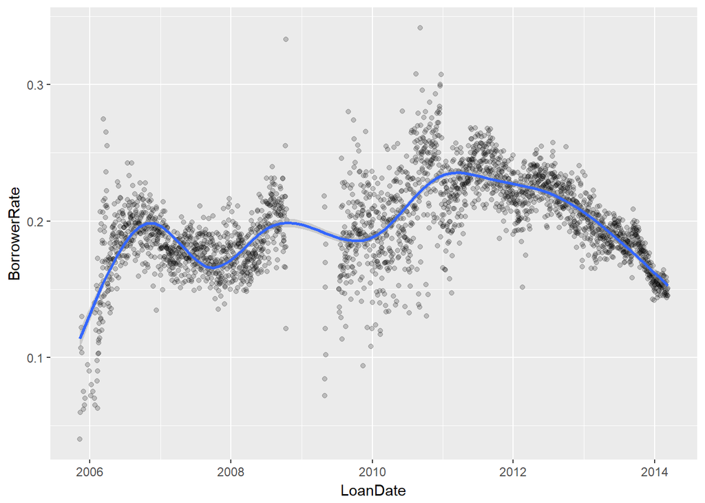

One thing that is striking when plotting the average BorrowerRate over time is the gap from the end of 2008 until the beginning of 2009. It seems that during this time no new loans were issued. Subsetting the dataset revealed that there a no loans between 2008-10-16 and 2009-04-28. This gap kind of coincides with the introduction of the new ProsperRating system, but I doubt that a new rating system is a reason to not issue new loans for several months. I can only speculate that the collapse of Lehman Brothers in 2008 might have played a role in this disruption.

The grand average BorrowerRate (indicated by the blue smoother) increases after the gap in 2009 to reach a peak in 2011. It decreases subsequently.

# Bivariate Analysis

### Talk about some of the relationships you observed in this part of the investigation. How did the feature(s) of interest vary with other features in the dataset?

I looked at the numbers of investors funding a loan and found that this in influenced by the sum that was loaned but also the rating of the loan and the interest rate (= yield for the investor). The number of investor slightly increases as the loaned sum increases. Investor numbers decrease from loans with the best to ones with the worst rating. Also interestingly investor numbers overall slighty decrease as the interest rate/yield increases.

I also looked at the status of the loans grouped by the rating of the loans. I found that the portion of loans that are in some way overdue or cancelled increase from the best to the worst rating. Also the portion of lower income customers increases from the best to the worst rating, while the portion of high income customers decreases.

### Did you observe any interesting relationships between the other features (not the main feature(s) of interest)?

Plotting the BorrowerRate over time I found an apparent disruption in the business. From October 2008 to April 2009 no new loans seem to have been issued.

I also found that there is a linear relationship between the monthly payment and the original amount of the loan. Interestingly there seem to be distinct groups paying different amounts per month for the same sum loaned.

### What was the strongest relationship you found?

The strongest relationship was probably between the rating of the loan and the BorrowerRate/LenderYield. There is apparently a linear increase in median interest rate from the best to the worst rating.

# Multivariate Plots Section

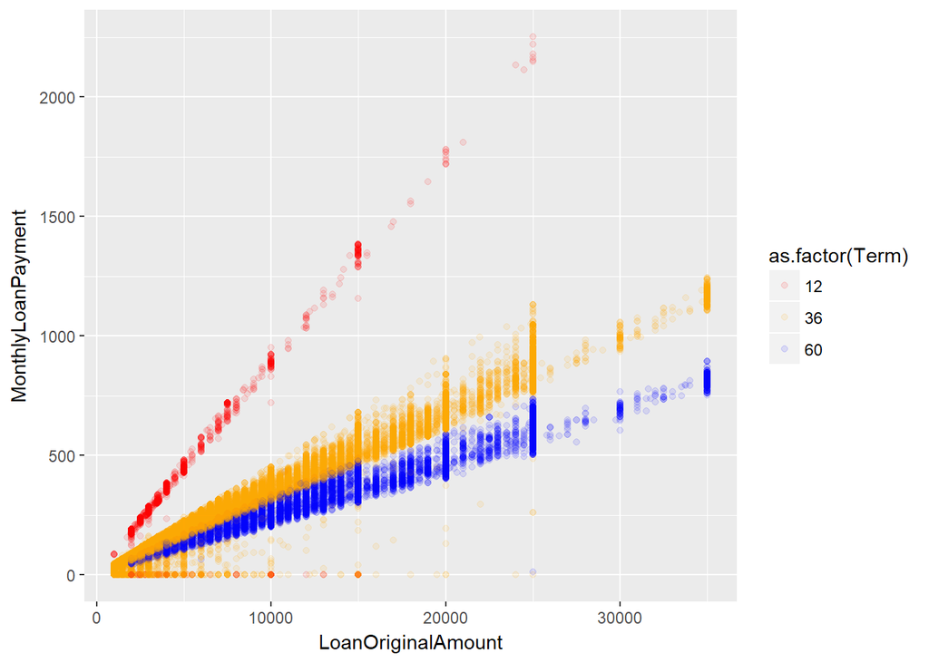

Coloring the scatterplot of LoanOriginalAmount vs MonthlyLoanPayment by Term, shows that the 3 groups originate from the 3 different term lengths. One can see that, the longer the term of the loan, thelower the monthly loan payment for the same total amount loaned. This is of course not surprising, since if you have to pay back the same amount of money loaned inless time, you have to pay more each month.

[figure not shown]

```
## sd$ProsperRating..Alpha._ordered: AA
##    Min. 1st Qu.  Median    Mean 3rd Qu.    Max.
## 0.04000 0.07325 0.07942 0.08110 0.08674 0.16000
## --------------------------------------------------------
## sd$ProsperRating..Alpha._ordered: A
##    Min. 1st Qu.  Median    Mean 3rd Qu.    Max.
## 0.07325 0.10474 0.11183 0.11189 0.11929 0.20980
## --------------------------------------------------------
## sd$ProsperRating..Alpha._ordered: B
##    Min. 1st Qu.  Median    Mean 3rd Qu.    Max.
##  0.1099  0.1454  0.1567  0.1573  0.1681  0.2657
## --------------------------------------------------------
## sd$ProsperRating..Alpha._ordered: C
##    Min. 1st Qu.  Median    Mean 3rd Qu.    Max.
##  0.0895  0.1899  0.2012  0.2021  0.2140  0.3500
## --------------------------------------------------------
## sd$ProsperRating..Alpha._ordered: D
##    Min. 1st Qu.  Median    Mean 3rd Qu.    Max.
##  0.1223  0.2414  0.2527  0.2517  0.2640  0.3415
## --------------------------------------------------------
## sd$ProsperRating..Alpha._ordered: E
##    Min. 1st Qu.  Median    Mean 3rd Qu.    Max.
##  0.1600  0.2818  0.3036  0.3012  0.3176  0.3500
## --------------------------------------------------------
## sd$ProsperRating..Alpha._ordered: HR
##    Min. 1st Qu.  Median    Mean 3rd Qu.    Max.
##  0.1823  0.3134  0.3177  0.3171  0.3199  0.3525
## --------------------------------------------------------
## sd$ProsperRating..Alpha._ordered: NC
## NULL
## --------------------------------------------------------
## sd$ProsperRating..Alpha._ordered:
## NULL
```

Next I was interested in how the mean interest rate for loans (BorrowerRate) changed over time and for the different loan ratings. There were two different rating systems in use at different points in time. I decided to only look at loans rated using the ProsperRating system, since this covers the majority of loans. The ProsperRating was introduced in 2009, so I will look at loans from ca. 2009 until 2014.

Overall one can see that the interest rates are clearly separated by the loan rating, meaning that there is a relationship between rating and interes rate. The mean interest rate increases from loans with the best rating (AA) to ones with the worst rating (E). The mean interest rate ranges from 0.08 (AA) to 0.30 (E). The “HR” rating seems to be even worse than “E”, as it has the highest mean interes rate of 0.31.

More noticably and interestingly, one can see a decrease in variance of the mean interest rate within each of the different ratings. At the beginning of this plot (2009), the mean interest rates are a lot less distinct between the grades than they are at the end (2014). For the most recent loans the mean interest rate is very clearly separated depending on the rating and it varies only to a narrow degree within each rating. This could indicate that over time the influence the loan rating on the interest rate has increased. So that while there used to be several variables determining the interest rate of any given loan, most recently the loan rating became the dominant factor. Another possibility is, that over time there were some changes in what loans got assigned which rating, so that loans with the same rating are in general more similar or uniform to each other.

# Multivariate Analysis

### Talk about some of the relationships you observed in this part of the investigation. Were there features that strengthened each other in terms of looking at your feature(s) of interest?

I observed that there are three distinct groups of monthly payment amounts for the same overall amount loaned. These three groups seem to be determined by the term of the loan. This seems be logical, since if you loan a certain amount of money, but one customer has to pay back the loan in less time than another customer, one has to pay more each month.

Another thing I observed is, that the mean interest is distinct for each of the loan ratings. So there seems to be a relationship between rating and interest rate. The mean interest rate for loan with the best rating (AA) is the lowest and increases from best to the worst rating (Equivalent to LenderYield by ProsperRating shown above).

### Were there any interesting or surprising interactions between features?

Interestingly the variance of the mean interest rate decreased over time for each rating. Comparing the interest rates for each rating in 2009 and 2014 shows a much clearer distinction between the different ratings. So one could speculate that the effect of the rating on the interest rate has increased over time.

# Final Plots and Summary

> **Tip**: You’ve done a lot of exploration and have built up an understanding of the structure of and relationships between the variables in your dataset. Here, you will select three plots from all of your previous exploration to present here as a summary of some of your most interesting findings. Make sure that you have refined your selected plots for good titling, axis labels (with units), and good aesthetic choices (e.g. color, transparency). After each plot, make sure you justify why you chose each plot by describing what it shows.

### Plot One

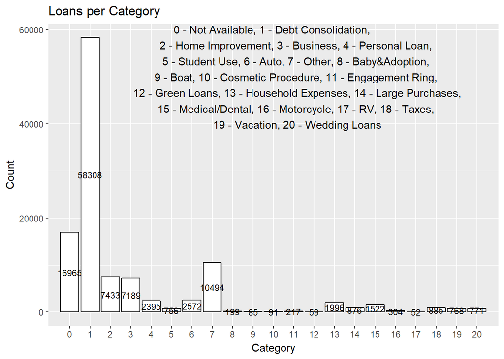

### Description One

One of the most interesting things for me during the univariate analysis, was the histogram of the ListingCategories. This allows for an insight in for what purpose customers took out a loan. To me it was quite surprising to see that around half of all the loans in the dataset were taken out in order to consolidate debt. Unfortunately the next most frequent categories were “Not Available” and “Other”, which are rather indescriptive regarding purpose. Other more frequent categories were “Home Improvement” and “Business”.